# New Orleans and the Changing Climate

Khalil Johnson

2/19/2016

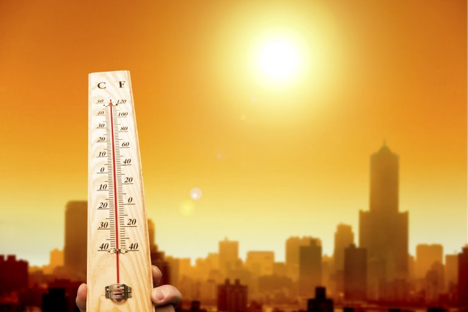

New Orleans Heat

## Where Do We See the Most Temperature Change in New Orleans?

In August of 2005 most of the nation watched as Hurricane Katrina devastated New Orleans. Suddenly, most of the nation came to the sobering realization that not only was climate change real, but a phenomenon that we would see much more of as time passed. The city of New Orleans has recovered since then, and is consistently on guard against inevitable threatening weather events as a result of climate change. In fact, over recent months The Picayune Times has repeatedly featured articles cautioning the public to prepare for unprecedented heat waves. The city is known for its particularly warm and humid weather, but as of late the birthplace of jazz has been fried like frog legs by record-breaking temperatures. Weather stations in and around the city have collected relevant data since 1900, and suggest an upward trend in temperatures, especially in the summer months.The data I collected came from the National Oceanic and Atmospheric Administration. Once retrieved, I was able to interpret the data by removing irrelevant numbers like “-9999” in order to have a cleaner graph. The hottest months have extended their stays, and that influence has caused fall months to warm. These spikes have made the city’s underserved communities more vulnerable, and as a region that is particularly sensitive to climate change, attention must be paid to these changes.With this blog I hope to apprise the New Orleans reader of the dangers and consequences of a heating local climate. New Orleans has some of the most concentrated poverty in the United States which leaves their community vulnerable to heat waves that will disproportionately impact them.

### Selecting for 1 Month – June

Perhaps, we can can understand the temperature change in New Orleans if we analyze for just one month at a time!

This is June

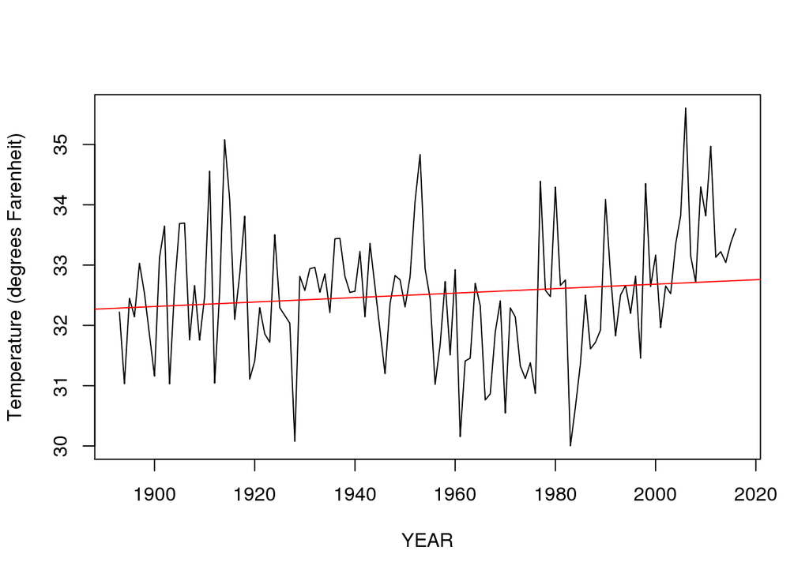

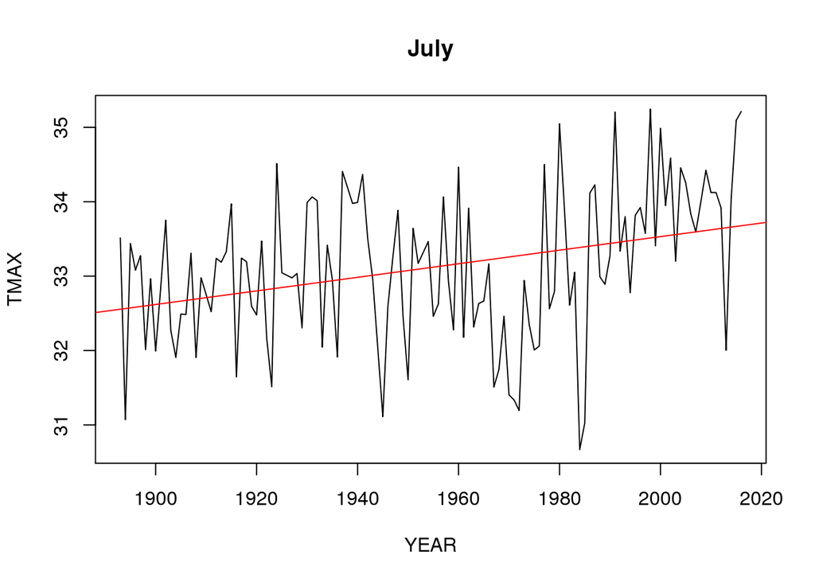

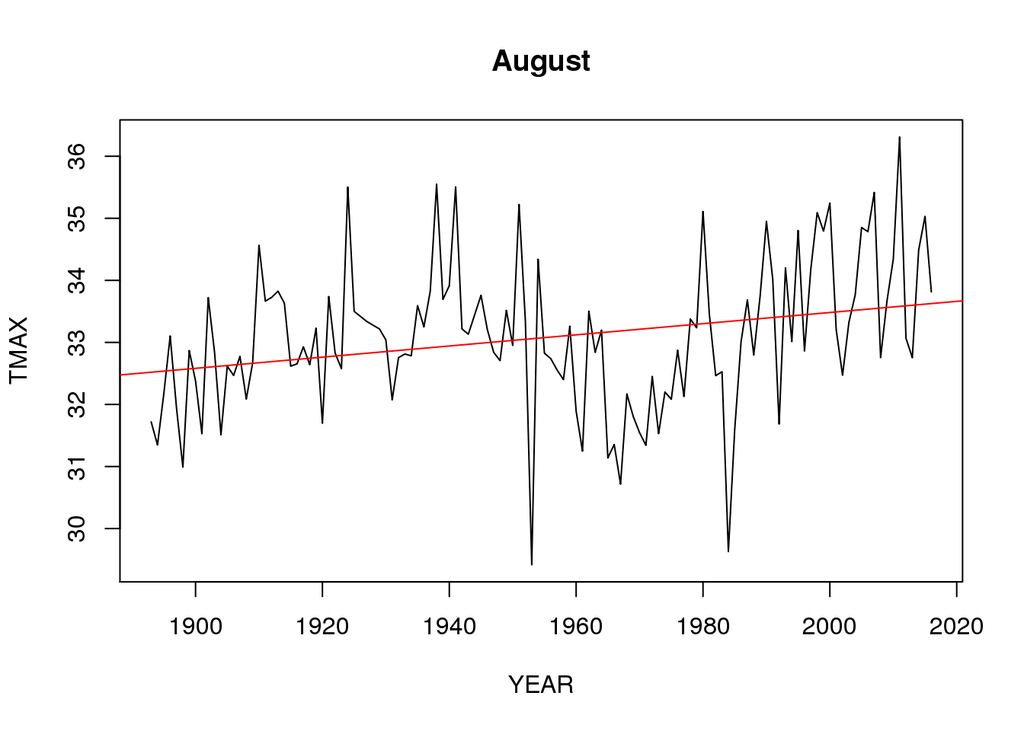

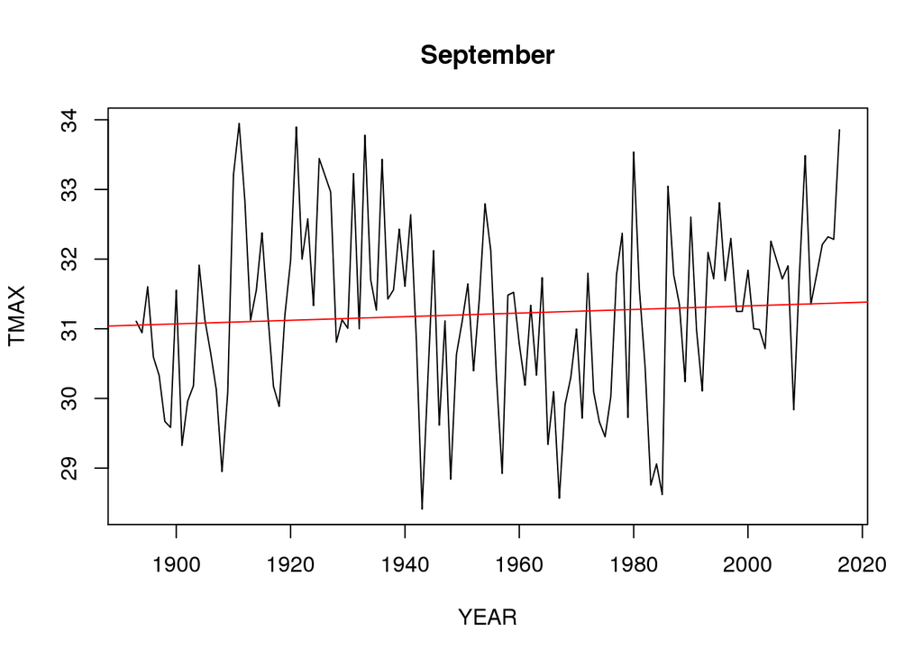

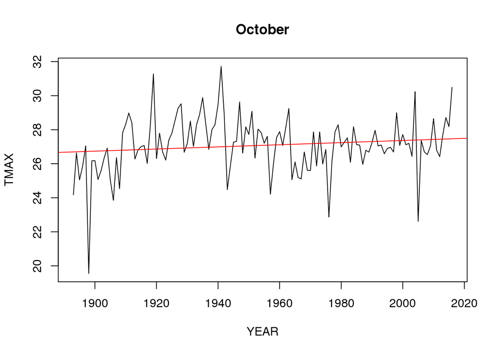

This will have an enourmous impact on vulnerable communities. Eliot Kamenitz of The Times-Picayune details the drastic efforts that the city must take to protect underserved citizens from the heat.

Heatwaves are the most dangerous weather events, and the number of deaths they claim are steadily on the rise. The dangerous mixture of both heat and moisture make for incredibly dangerous temperatures and humidity levels that all but ensure an emergency room full of heat stricken patients. Patrick Kinney, director of Climate and Health Program at Columbia Univresity, reported that heat-related deaths in the city of Manhatten for example may rise about 20% over the next decade as a result of climate change (Peeples,2013). This weather is descrimintatory in its impacts as well, especially in heat prone environments. African Americans are 50 times more likely than their white counterparts to live in such environments, therefore, having higher cases of heat related illnesses (Peeples, 2013). Socioeconomically depressed communities are also at a higher susceptibility to heatwaves because of their fear of high energy bills.

While the share of New Orleans’ poor residents living in neighborhoods dropped from 38% in 2000 to 30% in 2013 (Holmes,2015). There remains a heavy concentration of low income groups in places like the Orleans Parish. This socioeconomic disadvantage opens the doors for others as well, like health issues for example. Heatwaves excacerbate problems like these, and even create new ones: rashes, strokes, etc. The city of New Orleans must pay close attention to these temperature changes as climate changes progresses.

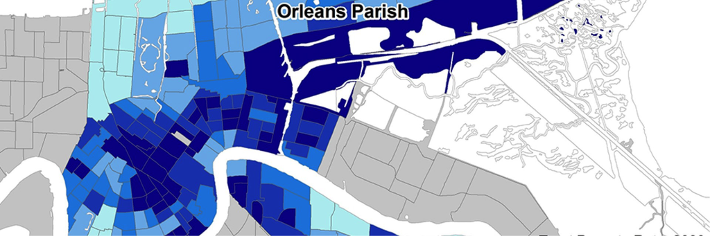

Poverty Concentration